# Practical Machine Learning: Prediction Assignment

Simone

3/2/2020

## Background

Using devices such as Jawbone Up, Nike FuelBand, and Fitbit it is now possible to collect a large amount of data about personal activity relatively inexpensively. The purpose of this project is to use data from accelerometers on the belt, forearm, arm, and dumbell of 6 participants which were asked to perform barbell lifts correctly and incorrectly in 5 different ways.

More information is available from the website here, from which the data come from (see the section on the Weight Lifting Exercise Dataset):  
- [Human Activity Recognition](http://web.archive.org/web/20161224072740/http:/groupware.les.inf.puc-rio.br/har)

The training and testing data for this project are also available for download here:  
- [Training Data](https://d396qusza40orc.cloudfront.net/predmachlearn/pml-training.csv)  
- [Testing Data](https://d396qusza40orc.cloudfront.net/predmachlearn/pml-testing.csv)

## Loading, cleaning and exploring the dataset

First, all the libraries needed for the analysis are loaded, and some constants related to the source data file are set.

```r
## Dependencies
library(lattice)
library(ggplot2)
library(MASS)
library(klaR)
library(e1071)
library(nlme)
library(mgcv)
library(randomForest)
library(caret)

# Set constants
trainingFileUrl <- "https://d396qusza40orc.cloudfront.net/predmachlearn/pml-training.csv"
trainingFileName <- "pml-training.csv"
testingFileUrl <- "https://d396qusza40orc.cloudfront.net/predmachlearn/pml-testing.csv"
testingFileName <- "pml-testing.csv"
```

Then the data files are downloaded if necessary, and imported as data.frame objects.

```r
# Downloading the raw data files, if necessary
if (!file.exists(trainingFileName)) {
  download.file(trainingFileUrl, destfile = trainingFileName, method = "curl")
}
if (!file.exists(testingFileName)) {
  download.file(testingFileUrl, destfile = testingFileName, method = "curl")
}

## Read the datasets
training_raw <- read.csv(trainingFileName)
testing_raw <- read.csv(testingFileName)
```

Some pre-cleaning is performed, removing all the rows which have **new_window = “yes”** (since their format is different).

```r
## Remove the new_window == "yes" records
training <- training_raw[training_raw$new_window == "no", ]
testing <- testing_raw[testing_raw$new_window == "no", ] # For consistence, but there is actually no need

## Check the records by user_name and classe
with(training, table(user_name, classe))
```

```
##           classe
## user_name     A    B    C    D    E
##   adelmo   1141  761  736  507  664
##   carlitos  822  674  485  478  597
##   charles   878  729  523  628  697
##   eurico    847  583  482  570  534
##   jeremy   1158  475  636  506  550
##   pedro     625  496  490  458  486
```

We can see that the **classe**, which indicates the way the activity is performed, is spread quite evenly among the variable **user_name**, which indicates who performed it.  
For the moment, we will not consider the variable **user_name** for the classification problem, as we would like to rely only on the information from the sensors to determine the **classe**.

```r
## Check which columns have NA values
column_NA <- as.data.frame(table(apply(is.na(training), 2, sum)))
colnames(column_NA) <- c("NA_count", "frequency")
column_NA
```

```
##   NA_count frequency
## 1        0        93
## 2    19216        67
```

There are some columns which contain NA values (and some other empty columns); we are going to remove them, plus transforming any remaining column as numeric, to ensure that they are in the right format for further data processing with machine learning algorithms.

```r
## Select only the columns with numeric data plus the column to predict
training <- training[, grep("^(roll|pitch|yaw|total_accel|gyros|accel|magnet)|classe", colnames(training))]
testing <- testing[, grep("^(roll|pitch|yaw|total_accel|gyros|accel|magnet)|problem_id", colnames(testing))]

## Ensure every column except the last one is numeric
training[, 1:52] <- sapply(training[, 1:52], as.numeric)
testing[, 1:52] <- sapply(testing[, 1:52], as.numeric)

## Recheck column with NA values
column_NA_new <- as.data.frame(table(apply(is.na(training), 2, sum)))
colnames(column_NA_new) <- c("NA_count", "frequency")
column_NA_new
```

```
##   NA_count frequency
## 1        0        53
```

Finally we are going to check the final dimensions of the training and testing sets, and that their column names are the same (except the last one, which indicates the **classe** in the training set, and the **problem_id** in the testing set).

```r
## Check the dimensions and that the column names are the same between the training and testing sets
dim(training)
```

```
## [1] 19216    53
```

```r
dim(testing)
```

```
## [1] 20 53
```

```r
sum(colnames(training)[1:52] != colnames(testing)[1:52])
```

```
## [1] 0
```

## Train the machine learning models

Before applying the machine learning algorithms, we are going to normalize all the numeric columns in the training set (mean = 0, standard deviation = 1; we are later going to reuse the same column-wise normalization parameters for the testing set), set k = 10 (for the k-fold cross validation), initialize the random seed, create the 10 different folds, and initialize as empty vectors the variables that we will use to track accuracy during cross validation.

```r
## Normalize the columns based on the training set
col_mean <- as.list(apply(training[, 1:52], 2, mean))
col_sd <- as.list(apply(training[, 1:52], 2, sd))
for (column in colnames(training[, 1:52])) {
  training[, column] <- (training[, column] - col_mean[[column]]) / col_sd[[column]]
}

## Set constant for k-fold cross validation
k = 10

## Set random seed
set.seed(12345)

## Create the folds
folds <- createFolds(y = training$classe, k = k, list = TRUE, returnTrain = TRUE)

## Initialize the summary variables
acc_train_set_1 <-  numeric(k)
acc_train_set_2 <-  numeric(k)
acc_train_set_3 <-  numeric(k)
acc_train_set_comb <-  numeric(k)
acc_cv_set_1 <-  numeric(k)
acc_cv_set_2 <-  numeric(k)
acc_cv_set_3 <-  numeric(k)
acc_cv_set_comb <-  numeric(k)
```

We are going to train 4 different models (all of them with default parameters):

- **Linear discriminant analysis**: variable **modFit1**
- **Random forest**: variable **modFit2**
- **Support vector machine**: variable **modFit3**
- **Stacked Model** (by stacking the 3 models together using random forest on top): variable **combModFit**

Each model is going to be trained on every fold (the data is split in a **train_set** - for training - and a **cv_set** - for cross validation - based on the indices in the fold), and its prediction accuracies on both the **train_set** and **cv_set** will be recorded in the vectors previously initialized.

```r
## Train and cross validate on every fold
for (i in 1:k) {

  ## Use the indices from the fold i
  train_set <- training[folds[[i]], ]
  cv_set <- training[-folds[[i]], ]

  ## On train set

  ## Linear discriminant analysis
  modFit1 <- train(classe ~ ., data = train_set, method = "lda")
  pred_train_set_1 <- predict(modFit1, train_set)
  acc_train_set_1[i] <- mean(pred_train_set_1 == train_set$classe)

  ## Random forest
  modFit2 <- randomForest(classe ~ ., data = train_set)
  pred_train_set_2 <- predict(modFit2, train_set)
  acc_train_set_2[i] <- mean(pred_train_set_2 == train_set$classe)

  ## Support vector machine
  modFit3 <- svm(classe ~ ., data = train_set)
  pred_train_set_3 <- predict(modFit3, train_set)
  acc_train_set_3[i] <- mean(pred_train_set_3 == train_set$classe)

  ## Stacking
  pred_train_set_DF <- data.frame(pred_1 = pred_train_set_1, pred_2 = pred_train_set_2,
                                  pred_3 = pred_train_set_3, classe = train_set$classe)
  combModFit <- train(classe ~ ., data = pred_train_set_DF, method = "rf")
  pred_train_set_comb <- predict(combModFit, pred_train_set_DF)
  acc_train_set_comb[i] <- mean(pred_train_set_comb == train_set$classe)

  ## On cross validation set

  ## Linear discriminant analysis
  pred_cv_set_1 <- predict(modFit1, cv_set)
  acc_cv_set_1[i] <- mean(pred_cv_set_1 == cv_set$classe)

  ## Random forest
  pred_cv_set_2 <- predict(modFit2, cv_set)
  acc_cv_set_2[i] <- mean(pred_cv_set_2 == cv_set$classe)

  ## Support vector machine
  pred_cv_set_3 <- predict(modFit3, cv_set)
  acc_cv_set_3[i] <- mean(pred_cv_set_3 == cv_set$classe)

  ## Stacking
  pred_cv_set_DF <- data.frame(pred_1 = pred_cv_set_1, pred_2 = pred_cv_set_2,
                               pred_3 = pred_cv_set_3, classe = cv_set$classe)
  pred_cv_set_comb <- predict(combModFit, pred_cv_set_DF)
  acc_cv_set_comb[i] <- mean(pred_cv_set_comb == cv_set$classe)

  }
```

## Selecting the best model using cross validation

After training, we are going to calculate the average accuracy of each model across the 10 data splits (folds). The results are presente in the tables and plot below.

```r
## Train
train_results <- as.data.frame(rbind(acc_train_set_1, acc_train_set_2, acc_train_set_3, acc_train_set_comb))
colnames(train_results) <- paste("Fold", 1:10)
row.names(train_results) <- c("Linear discriminant analysis", "Random forest", "Support vector machine",
                              "Stacked Model")
train_results$Average = apply(train_results, 1, mean)
round(train_results, 4)
```

```
##                              Fold 1 Fold 2 Fold 3 Fold 4 Fold 5 Fold 6 Fold 7
## Linear discriminant analysis 0.7061 0.7039 0.7047 0.7050 0.7067 0.7041 0.7047
## Random forest                1.0000 1.0000 1.0000 1.0000 1.0000 1.0000 1.0000
## Support vector machine       0.9567 0.9561 0.9552 0.9558 0.9553 0.9569 0.9547
## Stacked Model                1.0000 1.0000 1.0000 1.0000 1.0000 1.0000 1.0000
##                              Fold 8 Fold 9 Fold 10 Average
## Linear discriminant analysis 0.7056 0.7058  0.7040  0.7051
## Random forest                1.0000 1.0000  1.0000  1.0000
## Support vector machine       0.9545 0.9557  0.9633  0.9564
## Stacked Model                1.0000 1.0000  1.0000  1.0000
```

```r
## Cross validation
cv_results <- as.data.frame(rbind(acc_cv_set_1, acc_cv_set_2, acc_cv_set_3, acc_cv_set_comb))
colnames(cv_results) <- paste("Fold", 1:10)
row.names(cv_results) <- c("Linear discriminant analysis", "Random forest", "Support vector machine",
                              "Stacked Model")
cv_results$Average = apply(cv_results, 1, mean)
out_of_sample_accuracy <- cv_results["Random forest", "Average"]
round(cv_results, 4)
```

```
##                              Fold 1 Fold 2 Fold 3 Fold 4 Fold 5 Fold 6 Fold 7
## Linear discriminant analysis 0.6961 0.7043 0.7142 0.7112 0.6915 0.7137 0.6961
## Random forest                0.9927 0.9969 0.9943 0.9969 0.9974 0.9958 0.9990
## Support vector machine       0.9469 0.9464 0.9589 0.9475 0.9553 0.9495 0.9490
## Stacked Model                0.9927 0.9969 0.9943 0.9969 0.9974 0.9958 0.9990
##                              Fold 8 Fold 9 Fold 10 Average
## Linear discriminant analysis 0.6947 0.6844  0.7123  0.7019
## Random forest                0.9990 0.9964  0.9953  0.9964
## Support vector machine       0.9418 0.9490  0.9672  0.9511
## Stacked Model                0.9990 0.9964  0.9953  0.9964
```

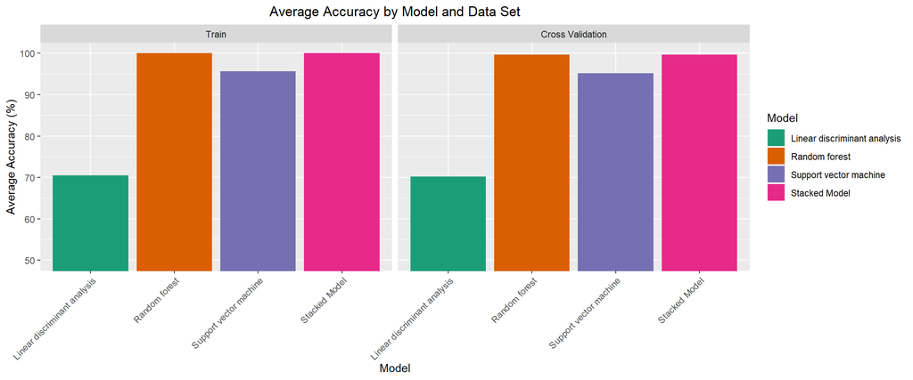

```r
## Plot of the accuracies
train_results$Model <- row.names(train_results)
train_results$Set <- rep("Train", times = 4)
cv_results$Model <- row.names(cv_results)
cv_results$Set <- rep("Cross Validation", times = 4)
results <- rbind(train_results, cv_results)
results$Set <- factor(results$Set, levels = c("Train", "Cross Validation"))
results$Model <- factor(results$Model, levels = c("Linear discriminant analysis", "Random forest",
                                                  "Support vector machine","Stacked Model"))
ggplot(results, aes(x = Model, y = Average * 100, fill = Model)) + coord_cartesian(ylim = c(50, 100)) +
  geom_bar(stat = "identity") + facet_grid(~ Set) + scale_fill_brewer(palette = "Dark2") +
  theme(plot.title = element_text(hjust = 0.5), axis.text.x = element_text(angle = 45, hjust = 1)) +
  labs(title = "Average Accuracy by Model and Data Set", y = "Average Accuracy (%)")
```

We can notice how, among the simple models, **Random forest** is performing betters than all the others (it has the highest average accuracy across the **train_set**s, and most importantly also across the **cv_set**s).  
**Stacked model** performs just as well, however it is more complex, since it is based on all the 3 simple models plus another random forest on top.  
For this reason, we select **Random forest** as the best model, and we estimate an out of sample accuracy using the average accuracy across the **cv_set**s: *99.64 %*.  
Then, we proceed to calculate the confusion matrix of the **Random forest** model:

```r
## Confusion matrix for the last model
confusionMatrix(cv_set$classe, pred_cv_set_2)
```

```
## Confusion Matrix and Statistics
##
##           Reference
## Prediction   A   B   C   D   E
##          A 545   1   0   0   1
##          B   1 369   1   0   0
##          C   0   4 331   1   0
##          D   0   0   0 315   0
##          E   0   0   0   0 353
##
## Overall Statistics
##
##                Accuracy : 0.9953
##                  95% CI : (0.9911, 0.9979)
##     No Information Rate : 0.2841
##     P-Value [Acc > NIR] : < 2.2e-16
##
##                   Kappa : 0.9941
##
##  Mcnemar's Test P-Value : NA
##
## Statistics by Class:
##
##                      Class: A Class: B Class: C Class: D Class: E
## Sensitivity            0.9982   0.9866   0.9970   0.9968   0.9972
## Specificity            0.9985   0.9987   0.9969   1.0000   1.0000
## Pos Pred Value         0.9963   0.9946   0.9851   1.0000   1.0000
## Neg Pred Value         0.9993   0.9968   0.9994   0.9994   0.9994
## Prevalence             0.2841   0.1946   0.1727   0.1644   0.1842
## Detection Rate         0.2836   0.1920   0.1722   0.1639   0.1837
## Detection Prevalence   0.2846   0.1930   0.1748   0.1639   0.1837
## Balanced Accuracy      0.9984   0.9927   0.9969   0.9984   0.9986
```

## Predictions on the testing set

```r
## Predict final results
for (column in colnames(testing[, 1:52])) {
  testing[, column] <- (testing[, column] - col_mean[[column]]) / col_sd[[column]]
}
pred_test_set_1 <- predict(modFit1, testing)
pred_test_set_2 <- predict(modFit2, testing)
pred_test_set_3 <- predict(modFit3, testing)
pred_test_set_DF <- data.frame(pred_1 = pred_test_set_1, pred_2 = pred_test_set_2, pred_3 = pred_test_set_3)
testing$predicted_classe <- predict(combModFit, pred_test_set_DF)
data.frame(problem_id = testing$problem_id, predicted_classe = testing$predicted_classe)
```

```
##    problem_id predicted_classe
## 1           1                B
## 2           2                A
## 3           3                B
## 4           4                A
## 5           5                A
## 6           6                E
## 7           7                D
## 8           8                B
## 9           9                A
## 10         10                A
## 11         11                B
## 12         12                C
## 13         13                B
## 14         14                A
## 15         15                E
## 16         16                E
## 17         17                A
## 18         18                B
## 19         19                B
## 20         20                B
```